# HW2-chapter5

Guangjin Zhou

February 21, 2019

## R libraries

```r
library(boot)

library(MASS);
names(Boston);dim(Boston);str(Boston)
```

```
##  [1] "crim"    "zn"      "indus"   "chas"    "nox"     "rm"      "age"
##  [8] "dis"     "rad"     "tax"     "ptratio" "black"   "lstat"   "medv"
```

```
## [1] 506  14
```

```
## 'data.frame':    506 obs. of  14 variables:
##  $ crim   : num  0.00632 0.02731 0.02729 0.03237 0.06905 ...
##  $ zn     : num  18 0 0 0 0 0 12.5 12.5 12.5 12.5 ...
##  $ indus  : num  2.31 7.07 7.07 2.18 2.18 2.18 7.87 7.87 7.87 7.87 ...
##  $ chas   : int  0 0 0 0 0 0 0 0 0 0 ...
##  $ nox    : num  0.538 0.469 0.469 0.458 0.458 0.458 0.524 0.524 0.524 0.524 ...
##  $ rm     : num  6.58 6.42 7.18 7 7.15 ...
##  $ age    : num  65.2 78.9 61.1 45.8 54.2 58.7 66.6 96.1 100 85.9 ...
##  $ dis    : num  4.09 4.97 4.97 6.06 6.06 ...
##  $ rad    : int  1 2 2 3 3 3 5 5 5 5 ...
##  $ tax    : num  296 242 242 222 222 222 311 311 311 311 ...
##  $ ptratio: num  15.3 17.8 17.8 18.7 18.7 18.7 15.2 15.2 15.2 15.2 ...
##  $ black  : num  397 397 393 395 397 ...
##  $ lstat  : num  4.98 9.14 4.03 2.94 5.33 ...
##  $ medv   : num  24 21.6 34.7 33.4 36.2 28.7 22.9 27.1 16.5 18.9 ...
```

# 9.

We will now consider the Boston housing data set, from the MASS library.

## (a)

Based on this data set, provide an estimate for the population mean of medv. Call this estimate ^??.

```r
mean(Boston$medv)
```

```
## [1] 22.53281
```

So the estimated ^?? of median Baston area owner-occupied homes price 22.53 K.

## (b)

Provide an estimate of the standard error of ^??. Interpret this result.

Hint: We can compute the standard error of the sample mean by dividing the sample standard deviation by the square root of the number of observations.

```r
sd(Boston$medv)/sqrt(nrow(Boston))
```

```
## [1] 0.4088611
```

## (c)

Now estimate the standard error of ^?? using the bootstrap. How does this compare to your answer from (b)?

```r
set.seed(471)
meanFunc <- function(x,i){mean(x[i])}

x<-Boston$medv

mean.bt<-boot(data=x,statistic=meanFunc,R=1000);mean.bt;
```

```
##
## ORDINARY NONPARAMETRIC BOOTSTRAP
##
##
## Call:
## boot(data = x, statistic = meanFunc, R = 1000)
##
##
## Bootstrap Statistics :
##     original      bias    std. error
## t1* 22.53281 -0.02125652   0.4189001
```

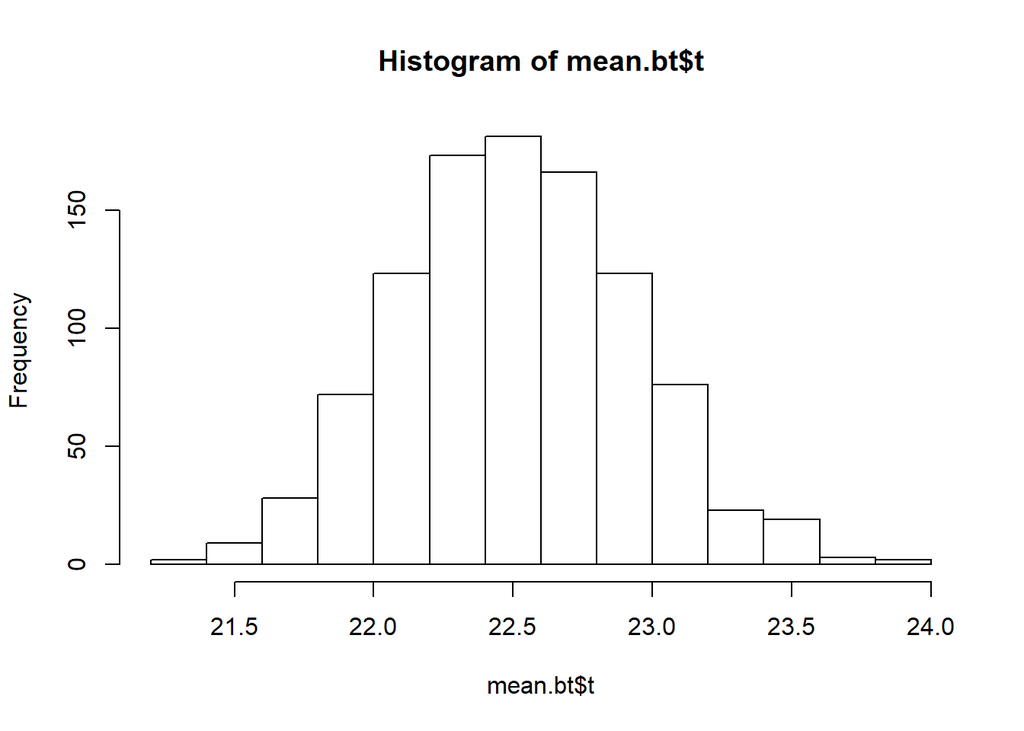

```r
hist(mean.bt$t)
```

```r
original.mean<-mean.bt$t0; original.mean
```

```
## [1] 22.53281
```

```r
bias.mean<-(mean(mean.bt$t)-mean.bt$t0);bias.mean
```

```
## [1] -0.02125652
```

```r
std.mean<-sd(mean.bt$t);std.mean
```

```
## [1] 0.4189001
```

## (d)

Based on your bootstrap estimate from (c), provide a 95% confidence interval for the mean of medv. Compare it to the results obtained using t.test(Boston$medv).

Hint: You can approximate a 95% confidence interval using the formula [^?? ??? 2SE(^??), ^?? + 2SE(^??)].

```r
t.test(Boston$medv)
```

```
##
##  One Sample t-test
##
## data:  Boston$medv
## t = 55.111, df = 505, p-value < 2.2e-16
## alternative hypothesis: true mean is not equal to 0
## 95 percent confidence interval:
##  21.72953 23.33608
## sample estimates:
## mean of x
##  22.53281
```

```r
upper<-mean(Boston$medv)+2*0.4189001
low<-mean(Boston$medv)-2*0.4189001
ci<-c(mean(Boston$medv),low,upper);ci
```

```
## [1] 22.53281 21.69501 23.37061
```

The 95% confidence interval for medv mean 22.53281 by bootstrap is 21.69501~23.37061. The t.test 95% confidence interval is 21.72953~23.33608.

## (e) Based on this data set, provide an estimate, ^??med, for the median value of medv in the population.

```r
median(Boston$medv)
```

```
## [1] 21.2
```

## (f)

We now would like to estimate the standard error of ^??med. Unfortunately, there is no simple formula for computing the standard error of the median. Instead, estimate the standard error of the median using the bootstrap. Comment on your findings.

```r
set.seed(471)
median.fn<-function(data,index) median(data[index])
x<-Boston$medv
f<-boot(data=x,statistic=median.fn,R=1000);f
```

```
##
## ORDINARY NONPARAMETRIC BOOTSTRAP
##
##
## Call:
## boot(data = x, statistic = median.fn, R = 1000)
##
##
## Bootstrap Statistics :
##     original   bias    std. error
## t1*     21.2 -0.03465   0.3813493
```

So the estimate of standard error of ^??med is 0.3813.

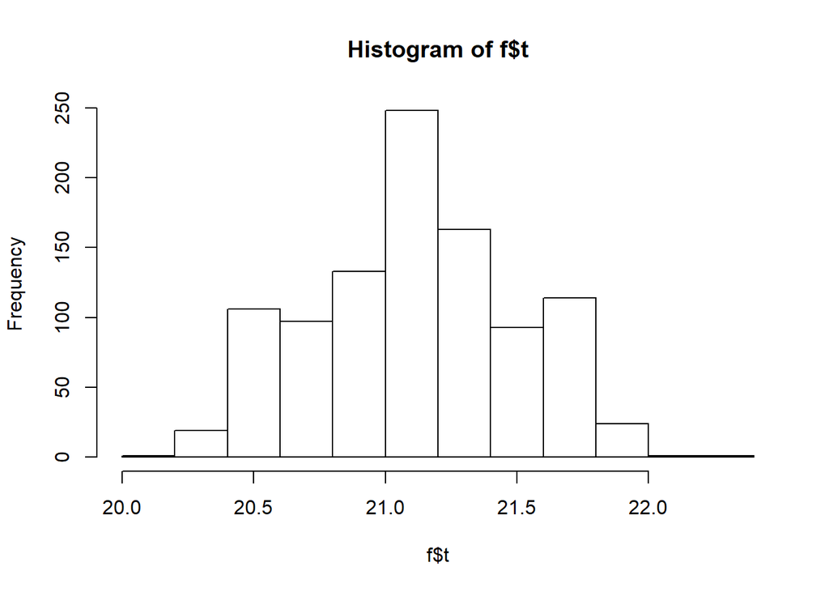

```r
hist(f$t)
```

```r
original.median<-f$t0; original.median
```

```
## [1] 21.2
```

```r
bias.median<-mean(f$t)-f$t0;bias.median
```

```
## [1] -0.03465
```

```r
std.median<-sd(f$t);std.median
```

```
## [1] 0.3813493
```

## (g)

Based on this data set, provide an estimate for the tenth percentile of medv in Boston suburbs. Call this quantity ^??0.1. (You can use the quantile() function.)

```r
mu0.1<-quantile(Boston$medv, prob=seq(0,1,0.1)); mu0.1
```

```
##    0%   10%   20%   30%   40%   50%   60%   70%   80%   90%  100%
##  5.00 12.75 15.30 18.20 19.70 21.20 22.70 24.15 28.20 34.80 50.00
```

So the 10th percentile of medv in Boston suburbs is 12.75 K.

## (h)

Use the bootstrap to estimate the standard error of ^??0.1. Comment on your findings.

### 1000 R bootstrap

```r
set.seed(471)
my10th<-function(data,index) quantile(data[index],.10)
h<-boot(data=mu0.1,statistic=my10th,R=1000);h
```

```
##
## ORDINARY NONPARAMETRIC BOOTSTRAP
##
##
## Call:
## boot(data = mu0.1, statistic = my10th, R = 1000)
##
##
## Bootstrap Statistics :
##     original   bias    std. error
## t1*    12.75 -0.69505    4.823175
```

### increase R value

```r
set.seed(471)
h2<-boot(data=mu0.1,statistic=my10th,R=100000);h2
```

```
##
## ORDINARY NONPARAMETRIC BOOTSTRAP
##
##
## Call:
## boot(data = mu0.1, statistic = my10th, R = 1e+05)
##
##
## Bootstrap Statistics :
##     original     bias    std. error
## t1*    12.75 -0.5249405    4.785577
```

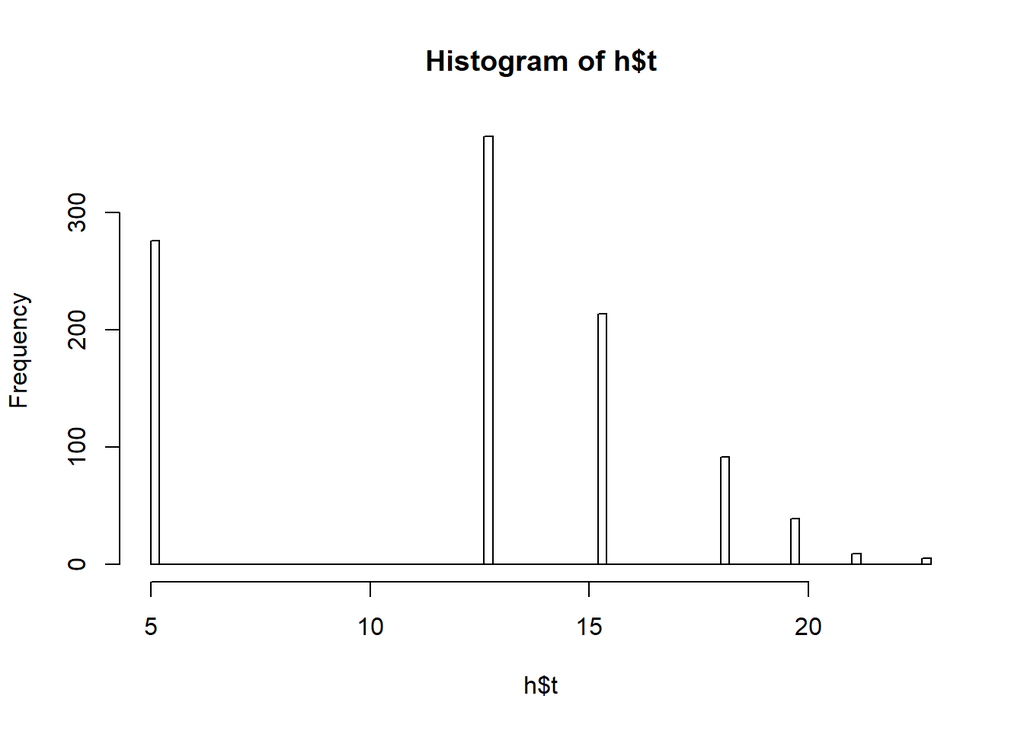

```r
hist(h$t, breaks=100);
```

```r
original.10th<-h$t0; original.10th
```

```
##   10%
## 12.75
```

```r
bias.10th<-mean(h$t)-h$t0;bias.10th
```

```
##      10%
## -0.69505
```

```r
std.10th<-sd(h$t);std.10th
```

```
## [1] 4.823175
```